# lab1

### Univariate Linear Regression on the California Housing Prices Dataset

1. Goal of the Report

The goal of this report is to create and test simple linear regression models to predict California house prices using three different factors: median income, population, and the number of households. We want to see how well each factor, by itself, can help explain or predict house prices in California. By working through this dataset, we aim to:

- **Understand the Dataset:** Gain insights into the structure and variables of the dataset, including demographic and housing information.
- **Data Cleaning and Preparation:** Perform necessary data cleaning and preprocessing steps to prepare the data for analysis.
- **Exploratory Data Analysis (EDA):** Conduct EDA to uncover patterns, correlations, and insights within the data.
- **Model Building:** Implement various machine learning algorithms to predict housing prices based on the available features.
- **Model Evaluation:** Evaluate the performance of the models using appropriate metrics and techniques.
- **Interpretation and Insights:** Interpret the results and derive meaningful insights from the models’ predictions.

2. Getting the data from source and loading it.

For this project, we are using the **California Housing Prices Dataset**. This dataset contains information about various factors that can influence housing prices in California, such as median income, population, and the number of households.

The dataset can be accessed from [Kaggle: California Housing Prices Dataset](https://www.kaggle.com/datasets/camnugent/california-housing-prices).

After downloading the dataset, let's load it into a Pandas DataFrame for further analysis and model building.

```python
import pandas as pd

# Load the dataset into a Pandas DataFrame
df = pd.read_csv('housing.csv')

# Display the first few rows of the dataset
df.head()
```

|  | longitude | latitude | housing_median_age | total_rooms | total_bedrooms | population | households | median_income | median_house_value | ocean_proximity |
| --- | --- | --- | --- | --- | --- | --- | --- | --- | --- | --- |
| 0 | -122.23 | 37.88 | 41.0 | 880.0 | 129.0 | 322.0 | 126.0 | 8.3252 | 452600.0 | NEAR BAY |
| 1 | -122.22 | 37.86 | 21.0 | 7099.0 | 1106.0 | 2401.0 | 1138.0 | 8.3014 | 358500.0 | NEAR BAY |
| 2 | -122.24 | 37.85 | 52.0 | 1467.0 | 190.0 | 496.0 | 177.0 | 7.2574 | 352100.0 | NEAR BAY |
| 3 | -122.25 | 37.85 | 52.0 | 1274.0 | 235.0 | 558.0 | 219.0 | 5.6431 | 341300.0 | NEAR BAY |
| 4 | -122.25 | 37.85 | 52.0 | 1627.0 | 280.0 | 565.0 | 259.0 | 3.8462 | 342200.0 | NEAR BAY |

#### 3.Exploratory Data Analysis (EDA)

3.1 Explore statistics (e.g. using Pandas `describe` and 'info' function)

```python
# Display summary statistics for numerical columns (e.g., mean, std, min, max, quartiles)
df.describe()
```

|  | longitude | latitude | housing_median_age | total_rooms | total_bedrooms | population | households | median_income | median_house_value |
| --- | --- | --- | --- | --- | --- | --- | --- | --- | --- |
| count | 20640.000000 | 20640.000000 | 20640.000000 | 20640.000000 | 20433.000000 | 20640.000000 | 20640.000000 | 20640.000000 | 20640.000000 |
| mean | -119.569704 | 35.631861 | 28.639486 | 2635.763081 | 537.870553 | 1425.476744 | 499.539680 | 3.870671 | 206855.816909 |
| std | 2.003532 | 2.135952 | 12.585558 | 2181.615252 | 421.385070 | 1132.462122 | 382.329753 | 1.899822 | 115395.615874 |
| min | -124.350000 | 32.540000 | 1.000000 | 2.000000 | 1.000000 | 3.000000 | 1.000000 | 0.499900 | 14999.000000 |
| 25% | -121.800000 | 33.930000 | 18.000000 | 1447.750000 | 296.000000 | 787.000000 | 280.000000 | 2.563400 | 119600.000000 |
| 50% | -118.490000 | 34.260000 | 29.000000 | 2127.000000 | 435.000000 | 1166.000000 | 409.000000 | 3.534800 | 179700.000000 |
| 75% | -118.010000 | 37.710000 | 37.000000 | 3148.000000 | 647.000000 | 1725.000000 | 605.000000 | 4.743250 | 264725.000000 |
| max | -114.310000 | 41.950000 | 52.000000 | 39320.000000 | 6445.000000 | 35682.000000 | 6082.000000 | 15.000100 | 500001.000000 |

```python
# Display basic information about the dataset (columns, data types, non-null values)
df.info()
```

```
<class 'pandas.core.frame.DataFrame'>
RangeIndex: 20640 entries, 0 to 20639
Data columns (total 10 columns):
 #   Column              Non-Null Count  Dtype
---  ------              --------------  -----
 0   longitude           20640 non-null  float64
 1   latitude            20640 non-null  float64
 2   housing_median_age  20640 non-null  float64
 3   total_rooms         20640 non-null  float64
 4   total_bedrooms      20433 non-null  float64
 5   population          20640 non-null  float64
 6   households          20640 non-null  float64
 7   median_income       20640 non-null  float64
 8   median_house_value  20640 non-null  float64
 9   ocean_proximity     20640 non-null  object
dtypes: float64(9), object(1)
memory usage: 1.6+ MB
```

3.2 Create three Seaborn scatter plots of median house value vs. median income, population and number of households. There should be one scatter plot per each independent variable. Add a title to each graph (using Seaborn).)

**Note:-** I am again loading the data in this code again so that I can structure it in a method for our defined class.

```
Data loaded successfully.
Data cleaned: 1165 rows removed.
```

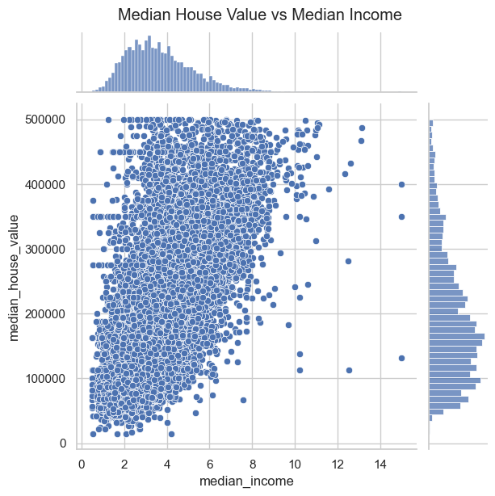

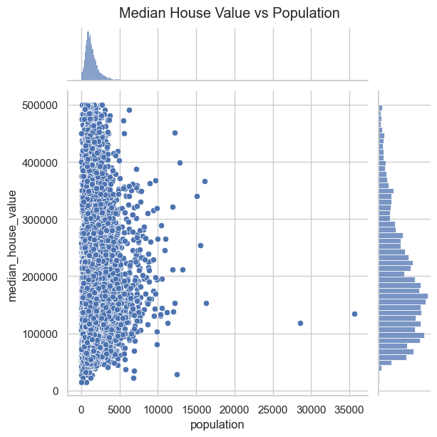

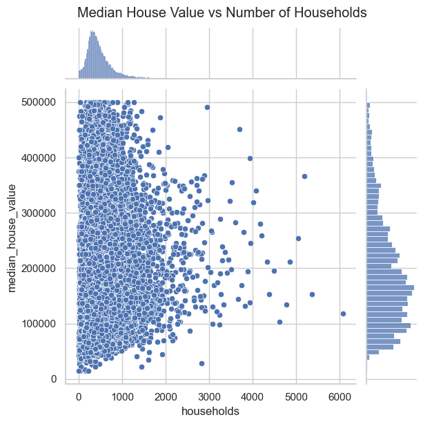

```python
import pandas as pd
import seaborn as sns
import matplotlib.pyplot as plt

class DataVisualizer:
    def __init__(self, file_path):
        self.file_path = file_path
        self.data = None

    def load_data(self):
        """Loads the dataset into a Pandas DataFrame."""
        try:
            self.data = pd.read_csv(self.file_path)
            print("Data loaded successfully.")
        except FileNotFoundError:
            print("Error: Dataset file not found.")
        except Exception as e:
            print(f"An error occurred while loading data: {e}")

    def clean_data(self):
        """Cleans the dataset by handling missing values and filtering unwanted values."""
        try:
            initial_shape = self.data.shape
            self.data.dropna(inplace=True)
            # Filter out median house values equal to 500001
            self.data = self.data[self.data['median_house_value'] != 500001]
            print(f"Data cleaned: {initial_shape[0] - self.data.shape[0]} rows removed.")
        except Exception as e:
            print(f"An error occurred while cleaning data: {e}")

    def plot_joint(self):
        """Generates joint scatter plots for median house value against other variables."""
        try:
            sns.set(style="whitegrid", color_codes=True)

            # Joint plot for median income
            g1 = sns.jointplot(x="median_income", y="median_house_value", data=self.data, kind="scatter")
            g1.fig.suptitle('Median House Value vs Median Income', y=1.02)

            # Joint plot for population
            g2 = sns.jointplot(x="population", y="median_house_value", data=self.data, kind="scatter")
            g2.fig.suptitle('Median House Value vs Population', y=1.02)

            # Joint plot for number of households
            g3 = sns.jointplot(x="households", y="median_house_value", data=self.data, kind="scatter")
            g3.fig.suptitle('Median House Value vs Number of Households', y=1.02)

            plt.show()

        except KeyError as e:
            print(f"Error: Column {e} not found in the dataset.")
        except Exception as e:
            print(f"An error occurred while plotting: {e}")

if __name__ == "__main__":
    file_path = 'E:/Conestoga/Foundation_of _Machine _Learning/Git_Repo/data/housing.csv'  # Specify the path to your dataset
    visualizer = DataVisualizer(file_path)

    visualizer.load_data()
    if visualizer.data is not None:
        visualizer.clean_data()
        visualizer.plot_joint()  # Call the joint plot method
```

3.3 Based on the above, describe the 4 variables used in this lab. Observations such as their meaning, range and additional characteristics that you notice.

**Median House Value:**  
**Meaning:**: This is the middle price of homes in the area, showing what most homes are worth.  
**Range:** It can be low or high, depending on where the houses are located.  
**Characteristics:** It gives a good idea of how the housing market is doing and what people are willing to pay for homes.

**Median Income:**  
**Meaning:** This shows the average income of people living in the area.  
**Range:** It varies, with some places having high incomes and others much lower.  
**Characteristics:** Higher incomes usually mean people can afford more expensive homes, which can raise house prices.

**Population:**  
**Meaning:** This is the total number of people living in the area.  
**Range:** It can be very small in rural areas or very large in cities.  
**Characteristics:** More people often means more demand for housing, which can drive up prices.

**Number of Households:**  
**Meaning:** This counts how many separate living units (like families or individuals) are in the area.  
**Range:** This can also vary widely based on location.  
**Characteristics:** A high number of households can indicate a need for more homes, influencing house prices.

4. Run three linear regressions (fitting) between :

- median house value vs. median income
- median house value vs. population
- median house value vs. number of households.

```python
# keeping it filtered
filtered_df = df.dropna()
print(f"Rows dropped: {len(df) - len(filtered_df)}")

filtered_df = filtered_df[filtered_df["median_house_value"] != 500001]
```

```
Rows dropped: 207
```

```python
from sklearn import linear_model
# Create linear regression objects
model_income = linear_model.LinearRegression()
model_population = linear_model.LinearRegression()
model_households = linear_model.LinearRegression()
```

```python
# Fit the model income
model_income.fit(df[["median_income"]], df[["median_house_value"]])
```

```
LinearRegression()
```

```python
# Fit the model population
model_population.fit(df[["population"]], df[["median_house_value"]])
```

```
LinearRegression()
```

```python
# Fit the model households
model_households.fit(df[["households"]], df[["median_house_value"]])
```

```
LinearRegression()
```

5. In a single table for all three linear regressions, provide per regression model

- Intercept and slope
- Mean Squared Error
- Mean Absolute Error

```python
from sklearn.metrics import mean_squared_error, mean_absolute_error

model_results = {
    'Model': ['Median Income', 'Population', 'Households'],
    'Intercept': [
        model_income.intercept_[0],
        model_population.intercept_[0],
        model_households.intercept_[0]
    ],
    'Slope': [
        model_income.coef_[0][0],
        model_population.coef_[0][0],
        model_households.coef_[0][0]
    ],
    'Mean Squared Error': [
        mean_squared_error(df["median_house_value"], model_income.predict(df[["median_income"]])),
        mean_squared_error(df["median_house_value"], model_population.predict(df[["population"]])),
        mean_squared_error(df["median_house_value"], model_households.predict(df[["households"]]))
    ],
    'Mean Absolute Error': [
        mean_absolute_error(df["median_house_value"], model_income.predict(df[["median_income"]])),
        mean_absolute_error(df["median_house_value"], model_population.predict(df[["population"]])),
        mean_absolute_error(df["median_house_value"], model_households.predict(df[["households"]]))
    ]
}

# Create a DataFrame for results
model_results_df = pd.DataFrame(model_results)

# Display the results
display(model_results_df)
```

|  | Model | Intercept | Slope | Mean Squared Error | Mean Absolute Error |
| --- | --- | --- | --- | --- | --- |
| 0 | Median Income | 45085.576703 | 41793.849202 | 7.011312e+09 | 62625.933791 |
| 1 | Population | 210436.262076 | -2.511753 | 1.330741e+10 | 91153.820095 |
| 2 | Households | 196928.577162 | 19.872775 | 1.325778e+10 | 90802.743243 |

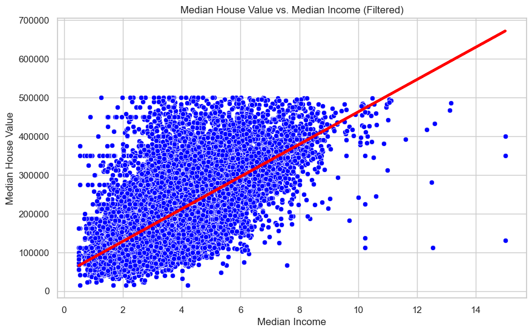

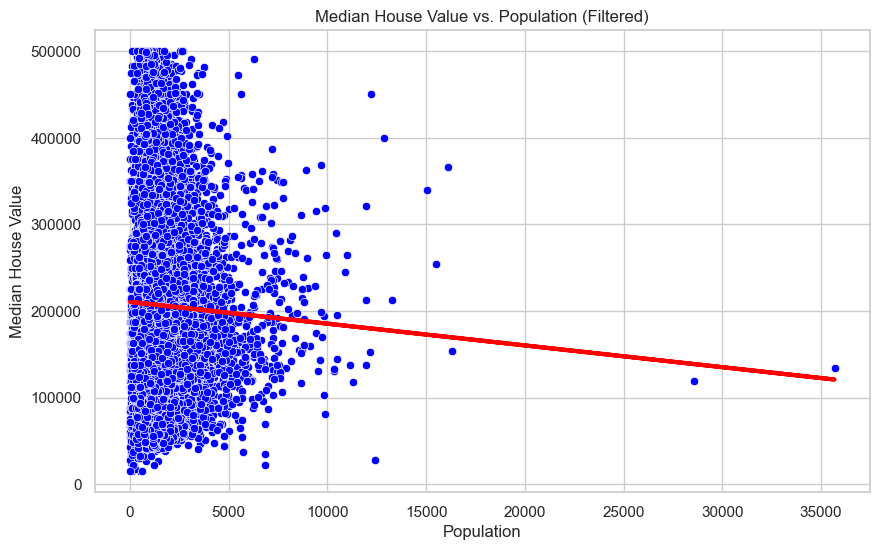

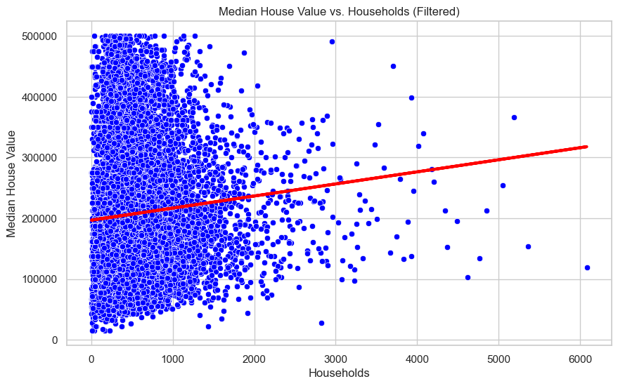

```python
import seaborn as sns
import matplotlib.pyplot as plt

# Plot for Median Income
plt.figure(figsize=(10, 6))
sns.scatterplot(x="median_income", y="median_house_value", data=filtered_df, color="blue")
plt.plot(filtered_df[["median_income"]], model_income.predict(filtered_df[["median_income"]]), color="red", linewidth=3)
plt.title('Median House Value vs. Median Income (Filtered)')
plt.xlabel('Median Income')
plt.ylabel('Median House Value')
plt.show()

# Plot for Population
plt.figure(figsize=(10, 6))
sns.scatterplot(x="population", y="median_house_value", data=filtered_df, color="blue")
plt.plot(filtered_df[["population"]], model_population.predict(filtered_df[["population"]]), color="red", linewidth=3)
plt.title('Median House Value vs. Population (Filtered)')
plt.xlabel('Population')
plt.ylabel('Median House Value')
plt.show()

# Plot for Households
plt.figure(figsize=(10, 6))
sns.scatterplot(x="households", y="median_house_value", data=filtered_df, color="blue")
plt.plot(filtered_df[["households"]], model_households.predict(filtered_df[["households"]]), color="red", linewidth=3)
plt.title('Median House Value vs. Households (Filtered)')
plt.xlabel('Households')
plt.ylabel('Median House Value')
plt.show()
```

7. Summary: provide a conclusion. Compare the models in terms of their goodness-of-fit, and add additional insights you observed

In this analysis, we looked at three models to predict house prices based on

1. median income
2. population
3. number of households

The model that used median income worked the best, showing a strong link to higher house prices.

The population model had surprising results, suggesting that more people might not always mean higher house prices, which was really unexpected for me. The households model faced similar issues and wasn't very effective at predicting prices.

Overall, median income turned out to be the best way to predict house values, showing that when incomes are higher, house prices tend to be higher too. These findings can help with decisions in real estate and policy.